# Juvenile Crime

2/16/2021

### Introduction

Many people, including members of our group, have noticed a growing concern about crimes committed by young adolescents and the rate of juvenile incarceration in the U.S. This provoked our group to research juvenile crime and incarceration, compare the rates of occurrence, and analyze the racial and gender factors that may show inequality in these crimes. We want to ask these questions about patterns in the rates of crime, where these crimes are happening, and who are committing these crimes because this type of information influences government attitudes and policy making.

*Some data-driven questions that we hope to answer are:*

1. What are the overall proportions of offenses caused by juveniles?
2. How have the rates of juvenile arrests changed over time?
3. Which state or region of the U.S. does juvenile incarceration seem most prevalent?

### Summary of Juvenile Crime Data

Based on the data, we have determined that the leading offense committed by juveniles (ages 0-17) is simple assault, making up 18.11% of all offenses committed by juveniles. Black juveniles have the greatest average arrest rate in the last 40 years, while Asian juveniles have the lowest arrest rate. Furthermore, Wyoming is the state with the highest rate of juvenile residential placement and Connecticut has the lowest rate of juvenile residential placement.

### Aggregated table of Juvenile Crime Data

| Year | Average Arrests of All The Races |
| --- | --- |
| 1980 | 6933 |
| 1981 | 7040 |
| 1982 | 7332 |
| 1983 | 6599 |
| 1984 | 6504 |
| 1985 | 6932 |
| 1986 | 7105 |
| 1987 | 7416 |
| 1988 | 8051 |
| 1989 | 8104 |
| 1990 | 7991 |
| 1991 | 8252 |
| 1992 | 8244 |
| 1993 | 8614 |
| 1994 | 9242 |
| 1995 | 9333 |
| 1996 | 9344 |
| 1997 | 9023 |
| 1998 | 7801 |
| 1999 | 7101 |
| 2000 | 6674 |
| 2001 | 6356 |
| 2002 | 6345 |
| 2003 | 6209 |
| 2004 | 6072 |
| 2005 | 6145 |
| 2006 | 6197 |
| 2007 | 6135 |
| 2008 | 5925 |
| 2009 | 5523 |
| 2010 | 4995 |
| 2011 | 4582 |
| 2012 | 4258 |
| 2013 | 3582 |
| 2014 | 3373 |
| 2015 | 3115 |
| 2016 | 2915 |
| 2017 | 2840 |
| 2018 | 2499 |
| 2019 | 2430 |

### Bar Chart on Top 10 Juvenile Offenses

**Purpose:** The bar chart represents the frequencies of the juvenile crime offenses, specifically the top ten offenses in 2019.

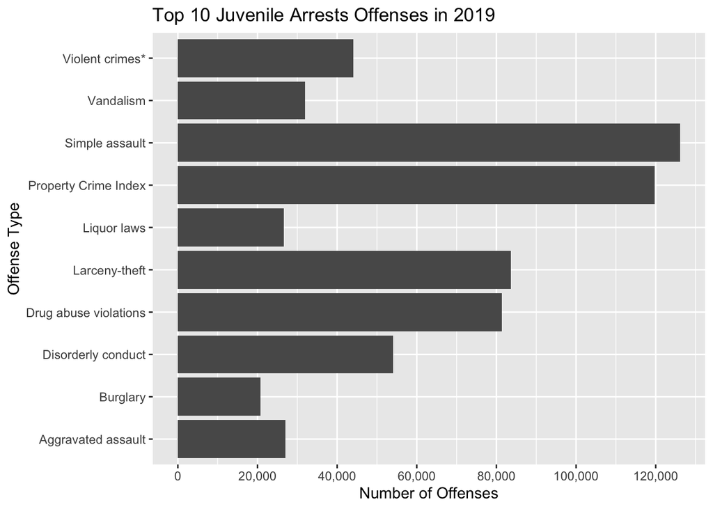

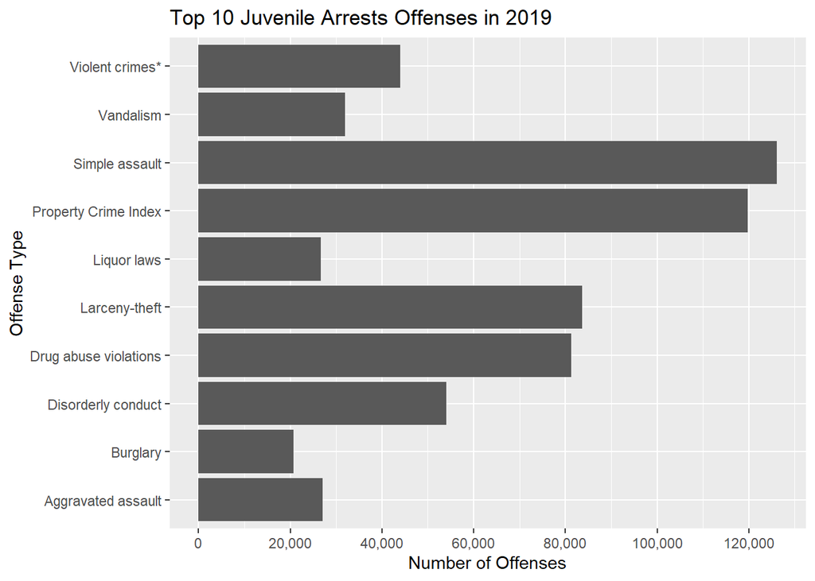

### Chart on Rates of Juvenile Arrests by Race Over Time

**Purpose:** This chart is intended to show the change in rates of juvenile arrests by race from 1980 to 2019. This visualization can help illustrate trends and patterns for specific races and time periods.

**Observations:** The rate of arrests are per 100,000 persons from ages 10-17. The chart shows that there was an increase of arrests between 1990 and 2000 and since then, there has been a gradual decline for all races. We can also see while the rates for all races follow the same trends, Black juveniles have the highest overall rate of arrest and Asian juveniles have the lowest.

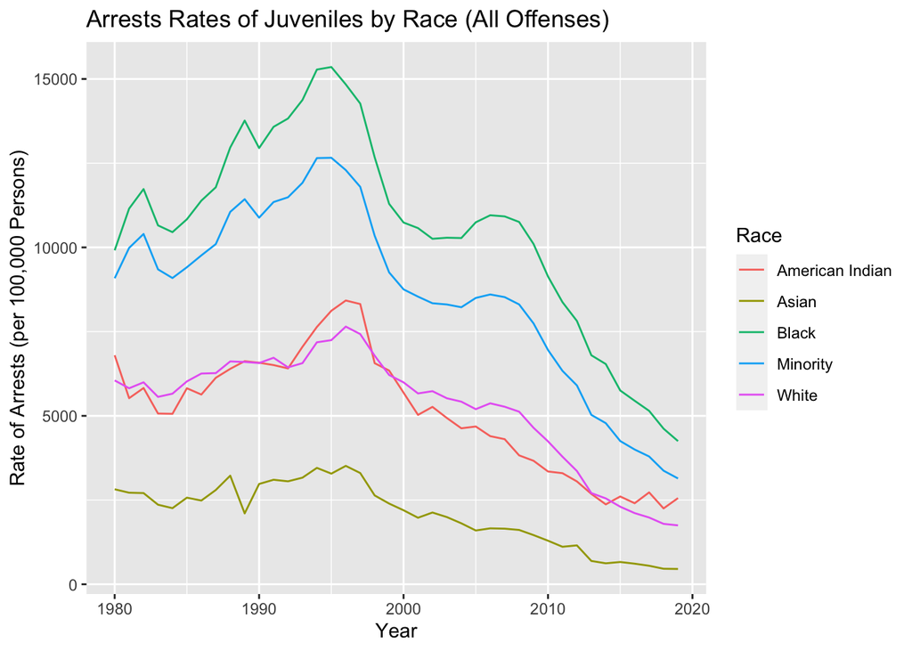

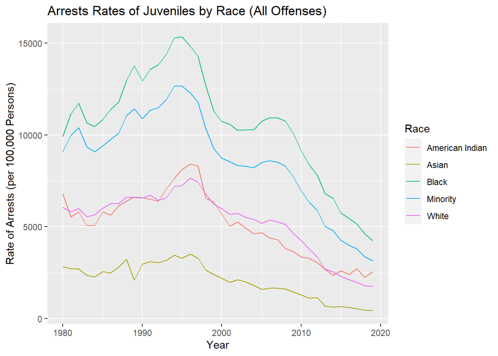

### Chart on Variation Of Total Juvenile Residential Placement Rates By States

**Purpose:** - This chart was intended to show the information of the total juvenile residential placement rate in U.S. varied by states in 2017. This chart is to show which state or region the juvenile incarceration seems most prevalent.

**Observations** - The residential placement rate is the number of juvenile offenders in residential placement per 100,000 juveniles age 10 through the upper age of original juvenile court jurisdiction in each state. In the data, we are able to see Wyoming having the highest rate, whereas Connecticut having the lowest rate.

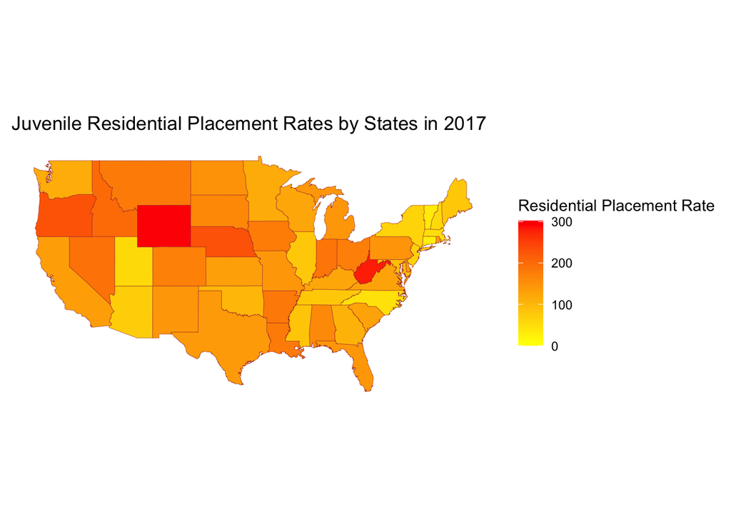

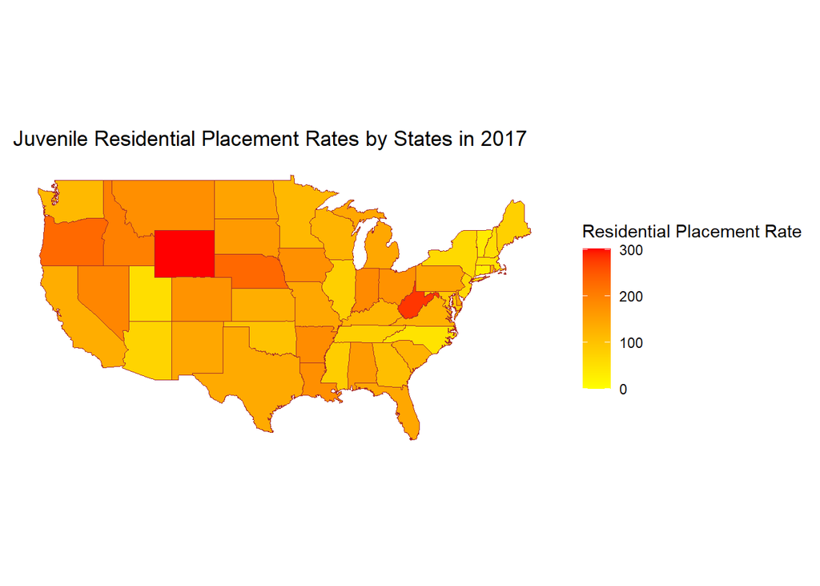